# Analyzing Individual BGG Users

Phil Henrickson

2022-01-01

# **Selfmade100aire’s** BoardGameGeek Collection

This notebook contains a set of analyses for the selected user’s boardgamegeek collection. The bulk of the analysis is focused on building a user-specific predictive model to predict the games that Selfmade100aire is likely to own. This enables to ask questions like, based on the games the user currently owns, what games are a good fit for their collection? What upcoming games are they likely to purchase?

This analysis is based on data from BoardGameGeek that was last updated on **2021-12-20.**

# 1 Collection Overview

We can look at a basic description of the number of games that the user owns, has rated, has previously owned, etc.

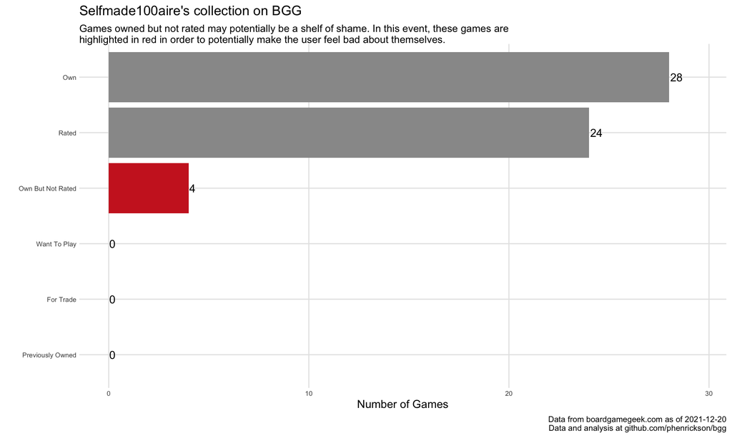

What years has the user owned/rated games from? While we can’t see when a user added or removed a game from their collection, we can look at their collection by the years in which their games were published.

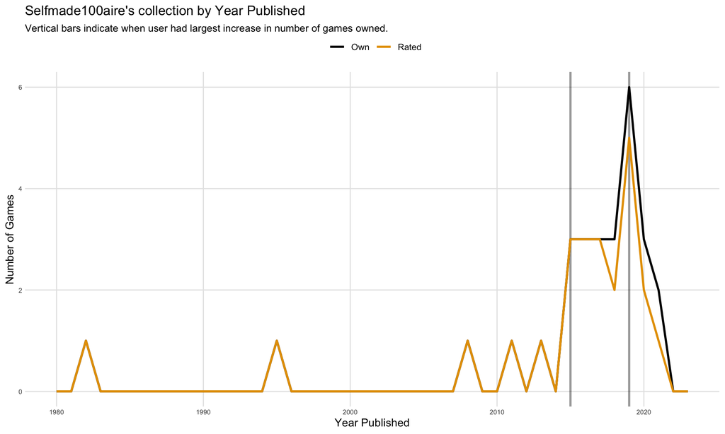

## 1.1 What types of games does Selfmade100aire own?

We can look at the most frequent types of categories, mechanics, designers, and artists that appear in a user’s collection.

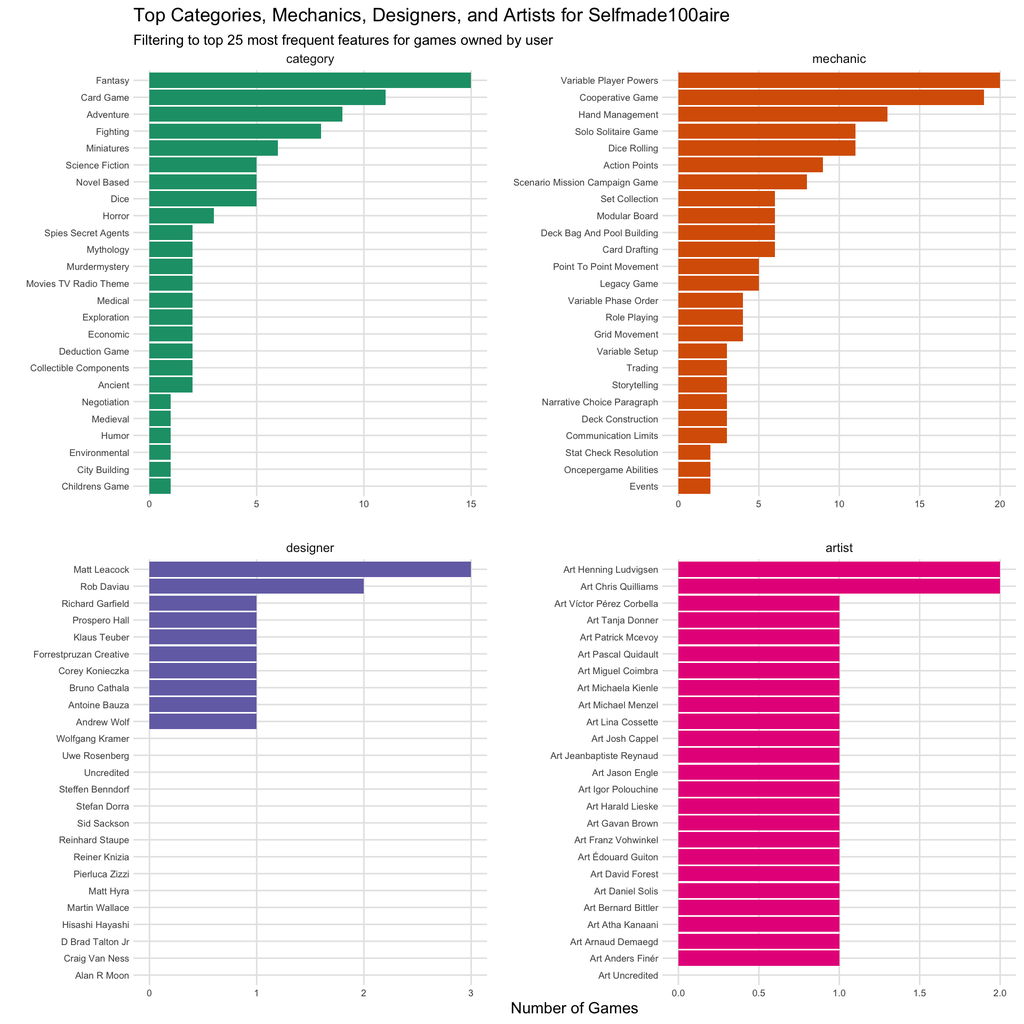

# 2 Modeling **Selfmade100aire’s** Collection

| username | dataset | period | games_owned | games_rated | games_played |
| --- | --- | --- | --- | --- | --- |
| Selfmade100aire | training | published before 2020 | 21 | 19 | 21 |
| Selfmade100aire | test | published 2020 or later | 5 | 3 | 5 |

There are two main (binary) outcomes we will be modeling for the user.

The first, **own** refers to whether the user currently lists a game as owned in their collection. The second, **played** refers to whether the user currently owns, has rated, or previously owned a game. This means the latter will generally have a larger list of games, but may still be a useful category to examine for people who play lots of games without necessarily owning them.

We will train predictive models to learn the probability that the user will own or play individual games based on their features.

## 2.1 Coefficients for Selfmade100aire

We can examine coefficients from the trained modes, which are penalized logistic regressions fit to our two main outcomes. Positive values indicate that a feature increases a user’s probabilility of owning/rating a game, while negative values indicate a feature decreases the probability.

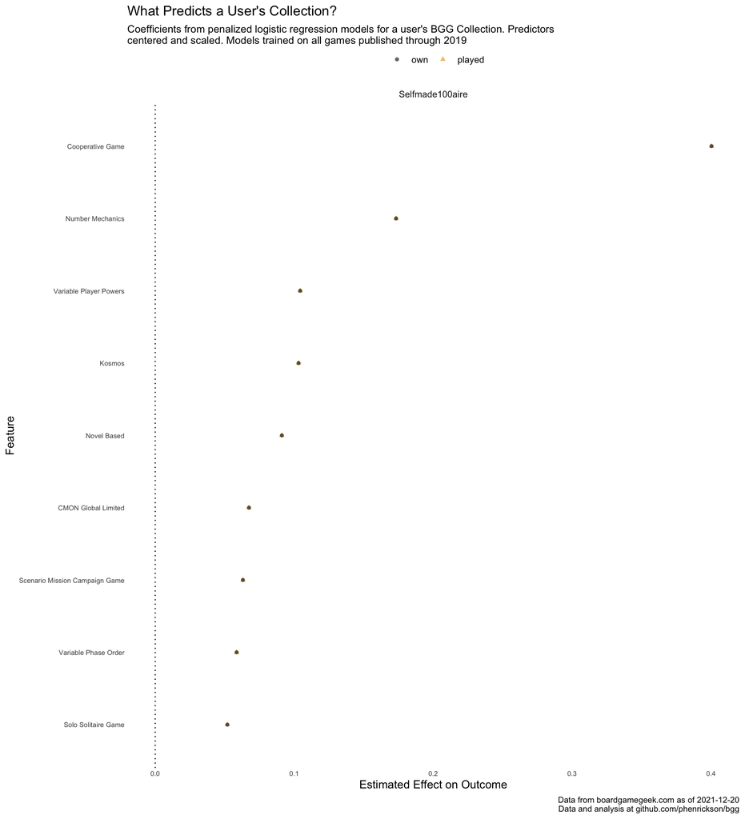

## 2.2 Visualizing Predictors for Selfmade100aire’s Collection

Why did the model identify these features? We can make density plots of the important features for predicting whether the user owned a game. Blue indicates the density for games owned by the user, while grey indicates the density for games not owned by the user.

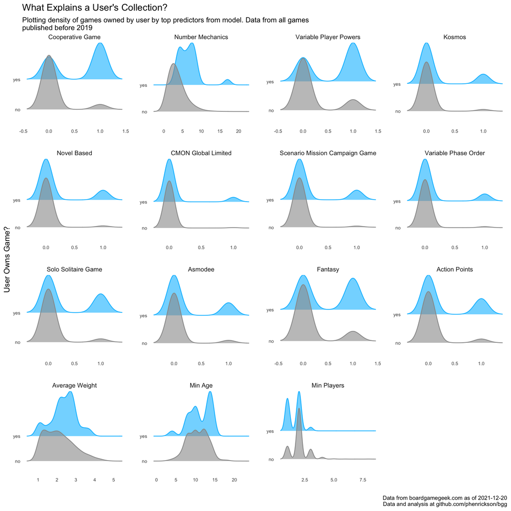

Binary predictors can be difficult to see with this visualization, so we can also directly examine the percentage of games in a user’s collection with a predictor vs the percentage of all games with that predictor.

| username | Feature | % of Games with Feature In_Collection | % of Games with Feature All_Games | Ratio |
| --- | --- | --- | --- | --- |
| Selfmade100aire | CMON Global Limited | 9.5% | 0.8% | 11.8 |
| Selfmade100aire | Scenario Mission Campaign Game | 19.0% | 2.3% | 8.2 |
| Selfmade100aire | Cooperative Game | 61.9% | 8.5% | 7.3 |
| Selfmade100aire | Novel Based | 19.0% | 2.8% | 6.9 |
| Selfmade100aire | Variable Phase Order | 14.3% | 2.1% | 6.8 |
| Selfmade100aire | Kosmos | 19.0% | 3.3% | 5.7 |
| Selfmade100aire | Solo Solitaire Game | 33.3% | 5.9% | 5.7 |
| Selfmade100aire | Asmodee | 23.8% | 5.4% | 4.4 |
| Selfmade100aire | Action Points | 28.6% | 6.9% | 4.2 |
| Selfmade100aire | Variable Player Powers | 61.9% | 17.0% | 3.6 |
| Selfmade100aire | Fantasy | 47.6% | 14.8% | 3.2 |
| Selfmade100aire | Horror | 9.5% | 4.0% | 2.4 |
| Selfmade100aire | Negotiation | 4.8% | 3.7% | 1.3 |
| Selfmade100aire | City Building | 4.8% | 4.3% | 1.1 |
| Selfmade100aire | Medieval | 4.8% | 6.3% | 0.8 |
| Selfmade100aire | Word Game | 0.0% | 1.8% | 0.0 |
| Selfmade100aire | Trivia | 0.0% | 1.8% | 0.0 |
| Selfmade100aire | Puzzle | 0.0% | 3.4% | 0.0 |
| Selfmade100aire | Party Game | 0.0% | 8.5% | 0.0 |
| Selfmade100aire | Racing | 0.0% | 2.8% | 0.0 |
| Selfmade100aire | Action Dexterity | 0.0% | 4.8% | 0.0 |
| Selfmade100aire | Mafia | 0.0% | 0.7% | 0.0 |
| Selfmade100aire | Trains | 0.0% | 2.2% | 0.0 |
| Selfmade100aire | Prehistoric | 0.0% | 1.0% | 0.0 |
| Selfmade100aire | Realtime | 0.0% | 4.2% | 0.0 |

# 3 Assess Model’s Performance on Training Set

Before predicting games in upcoming years, we can examine how well the model did and what games it liked in the training set. In this case, we used resampling techniques (cross validation) to ensure that the model had not seen a game before making its predictions.

## 3.1 Separation Plot

An easy way to examine the performance of classification model is to view a separation plot. We plot the predicted probabilities from the model for every game (from resampling) from lowest to highest. We then overlay a blue line for any game that the user does own. A good classifier is one that is able to *separate* the blue (games owned by the user) from the white (games not owned by the user), with most of the blue occurring at the highest probabilities (right side of the chart).

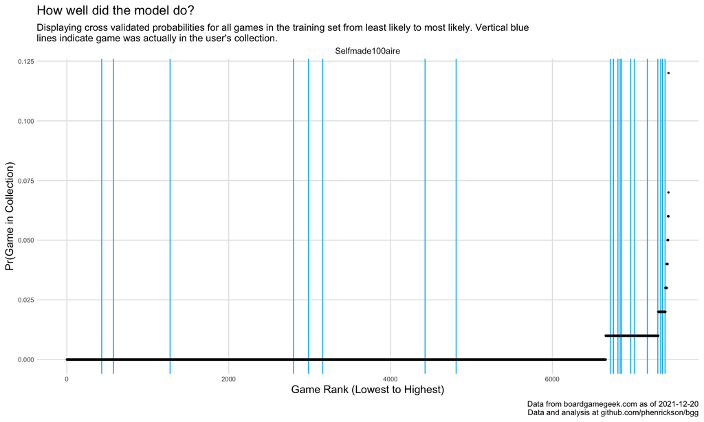

## 3.2 Top Games for **Selfmade100aire** from Training Set

We can display this information in table form, displaying the 100 games with the highest probability of ownership, adding a blue line when the user does own the game.

| username | yearpublished | game_id | name | pred_played | pred_own | actual_played | actual_own |
| --- | --- | --- | --- | --- | --- | --- | --- |
| Selfmade100aire | 2017 | 174430 | Gloomhaven | 0.12 | 0.12 | 0 | 0 |
| Selfmade100aire | 2017 | 188920 | This War of Mine: The Board Game | 0.07 | 0.07 | 0 | 0 |
| Selfmade100aire | 2018 | 231327 | The Grizzled: Armistice Edition | 0.06 | 0.06 | 0 | 0 |
| Selfmade100aire | 2019 | 207991 | Quodd Heroes | 0.06 | 0.06 | 0 | 0 |
| Selfmade100aire | 2019 | 248065 | Zombicide: Invader | 0.06 | 0.06 | 0 | 0 |
| Selfmade100aire | 2019 | 269385 | The Lord of the Rings: Journeys in Middle-Earth | 0.06 | 0.06 | 0 | 0 |
| Selfmade100aire | 2018 | 207243 | The City of Kings | 0.05 | 0.05 | 0 | 0 |
| Selfmade100aire | 2016 | 191189 | Aeon's End | 0.05 | 0.05 | 0 | 0 |
| Selfmade100aire | 2016 | 192153 | Pandemic: Reign of Cthulhu | 0.05 | 0.05 | 0 | 0 |
| Selfmade100aire | 2012 | 121921 | Robinson Crusoe: Adventures on the Cursed Island | 0.05 | 0.05 | 0 | 0 |
| Selfmade100aire | 2017 | 201186 | Summit: The Board Game | 0.05 | 0.05 | 0 | 0 |
| Selfmade100aire | 2012 | 113924 | Zombicide | 0.05 | 0.05 | 0 | 0 |
| Selfmade100aire | 2015 | 156548 | Super Dungeon Explore: Forgotten King | 0.05 | 0.05 | 0 | 0 |
| Selfmade100aire | 2019 | 264220 | Tainted Grail: The Fall of Avalon | 0.04 | 0.04 | 0 | 0 |
| Selfmade100aire | 2016 | 204305 | Sherlock Holmes Consulting Detective: Jack the Ripper & West End Adventures | 0.04 | 0.04 | 0 | 0 |
| Selfmade100aire | 2016 | 149787 | Perdition's Mouth: Abyssal Rift | 0.04 | 0.04 | 0 | 0 |
| Selfmade100aire | 2015 | 176189 | Zombicide: Black Plague | 0.04 | 0.04 | 0 | 0 |
| Selfmade100aire | 2018 | 224710 | Zombicide: Green Horde | 0.04 | 0.04 | 0 | 0 |
| Selfmade100aire | 1980 | 3248 | Citadel of Blood | 0.04 | 0.04 | 0 | 0 |
| Selfmade100aire | 2000 | 823 | The Lord of the Rings | 0.04 | 0.04 | 0 | 0 |
| Selfmade100aire | 2017 | 181524 | Masmorra: Dungeons of Arcadia | 0.04 | 0.04 | 0 | 0 |
| Selfmade100aire | 2011 | 91872 | Dungeons & Dragons: The Legend of Drizzt Board Game | 0.04 | 0.04 | 0 | 0 |
| Selfmade100aire | 2019 | 253344 | Cthulhu: Death May Die | 0.04 | 0.04 | 0 | 0 |
| Selfmade100aire | 2016 | 190400 | Aventuria: Adventure Card Game | 0.03 | 0.03 | 0 | 0 |
| Selfmade100aire | 2019 | 169427 | Middara: Unintentional Malum – Act 1 | 0.03 | 0.03 | 0 | 0 |
| Selfmade100aire | 2017 | 218417 | Aeon's End: War Eternal | 0.03 | 0.03 | 0 | 0 |
| Selfmade100aire | 2018 | 254193 | Fantastic Beasts: Perilous Pursuit | 0.03 | 0.03 | 0 | 0 |
| Selfmade100aire | 2010 | 65244 | Forbidden Island | 0.03 | 0.03 | 0 | 0 |
| Selfmade100aire | 2016 | 187687 | Pathfinder Adventure Card Game: Mummy's Mask – Base Set | 0.03 | 0.03 | 0 | 0 |
| Selfmade100aire | 2017 | 192135 | Too Many Bones | 0.03 | 0.03 | 0 | 0 |

[output cut: 70 more lines]

We can also more formally assess how well the model did in resampling by looking at the area under the receiver operating characteristic. A perfect model would receive a score of 1, while a model that cannot predict the outcome will default to a score of 0.5. The extent to which something is a *good* score depends on the setting, but generally anything in the .8 to .9 range is very good while the .7 to .8 range is perfectly acceptable.

| username | outcome_type | .metric | .estimator | .estimate |
| --- | --- | --- | --- | --- |
| Selfmade100aire | own | roc_auc | binary | 0.835 |
| Selfmade100aire | played | roc_auc | binary | 0.835 |

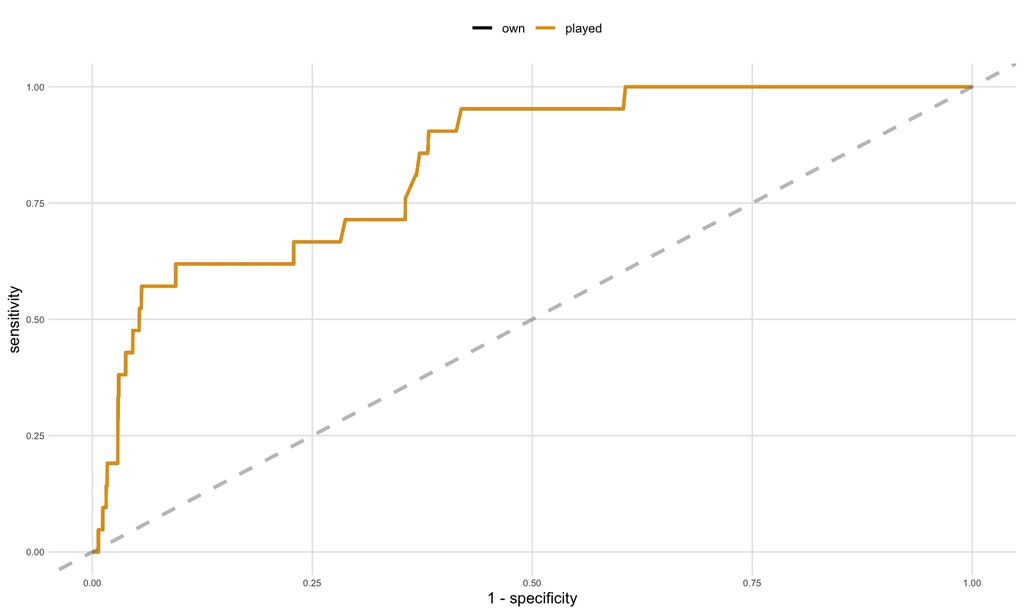

Another way to think about the model performance is to view its lift, or its ability to detect the positive outcomes over that of a null model. High lift indicates the model can much more quickly find all of the positive outcomes (in this case, games owned or played by the user), while a model with no lift is no better than random guessing.

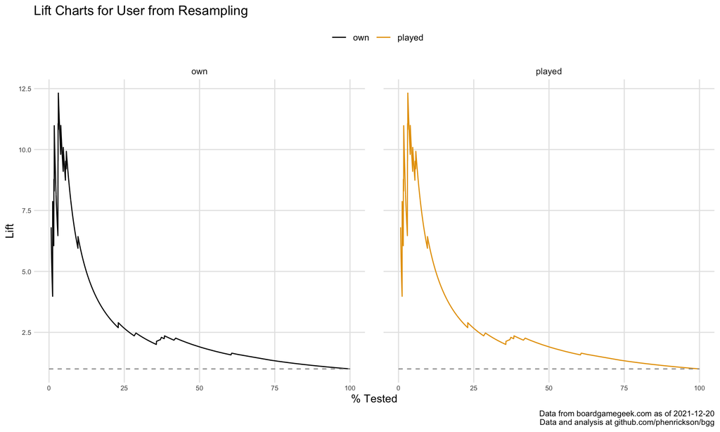

## 3.3 Most and Least Likely Games

What games does the model think Selfmade100aire is **most likely to own** that are **not** in their collection?

| username | yearpublished | game_id | name | pred_own | actual_own |
| --- | --- | --- | --- | --- | --- |
| Selfmade100aire | 2017 | 174430 | Gloomhaven | 0.12 | 0 |
| Selfmade100aire | 2017 | 188920 | This War of Mine: The Board Game | 0.07 | 0 |
| Selfmade100aire | 2018 | 231327 | The Grizzled: Armistice Edition | 0.06 | 0 |
| Selfmade100aire | 2019 | 207991 | Quodd Heroes | 0.06 | 0 |
| Selfmade100aire | 2019 | 248065 | Zombicide: Invader | 0.06 | 0 |

What games does the model think Selfmade100aire is **least likely to own** that **are** in their collection?

| username | yearpublished | game_id | name | pred_own | actual_own |
| --- | --- | --- | --- | --- | --- |
| Selfmade100aire | 2018 | 266966 | Dice Throne: Season Two – Gunslinger v. Samurai | 0 | 1 |
| Selfmade100aire | 2015 | 173346 | 7 Wonders Duel | 0 | 1 |
| Selfmade100aire | 2015 | 172287 | Champions of Midgard | 0 | 1 |
| Selfmade100aire | 1995 | 13 | Catan | 0 | 1 |
| Selfmade100aire | 2019 | 266507 | Clank!: Legacy – Acquisitions Incorporated | 0 | 1 |

## 3.4 Top Games by Year

Top 25 games most likely to be owned by the user in each year, highlighting in blue the games that the user has owned/played.

| rank | 2011 | 2012 | 2013 | 2014 | 2015 | 2016 | 2017 | 2018 | 2019 |
| --- | --- | --- | --- | --- | --- | --- | --- | --- | --- |
| 1 | Dungeons & Dragons: The Legend of Drizzt Board Game | Robinson Crusoe: Adventures on the Cursed Island | The Witches: A Discworld Game | Witness | Super Dungeon Explore: Forgotten King | Aeon's End | Gloomhaven | The Grizzled: Armistice Edition | Quodd Heroes |
| 2 | Elder Sign | Zombicide | The Hobbit: An Unexpected Journey | Shadows of Malice | Zombicide: Black Plague | Pandemic: Reign of Cthulhu | This War of Mine: The Board Game | The City of Kings | Zombicide: Invader |
| 3 | Dungeons & Dragons: Wrath of Ashardalon Board Game | Descent: Journeys in the Dark (Second Edition) | The Lord of the Rings Dice Building Game | Warfighter: The Tactical Special Forces Card Game | Sylvion | Sherlock Holmes Consulting Detective: Jack the Ripper & West End Adventures | Summit: The Board Game | Zombicide: Green Horde | The Lord of the Rings: Journeys in Middle-Earth |
| 4 | Gears of War: The Board Game | Legends of Andor | Eldritch Horror | Pandemic: The Cure | Albion's Legacy | Perdition's Mouth: Abyssal Rift | Masmorra: Dungeons of Arcadia | Fantastic Beasts: Perilous Pursuit | Tainted Grail: The Fall of Avalon |
| 5 | Star Trek: Expeditions | Freedom: The Underground Railroad | Room 25 | Consentacle | Burgle Bros. | Aventuria: Adventure Card Game | Aeon's End: War Eternal | Renegade | Cthulhu: Death May Die |
| 6 | The Secret of Monte Cristo | Bolt Action | Forbidden Desert | Onirim (Second Edition) | Journey: Wrath of Demons | Pathfinder Adventure Card Game: Mummy's Mask – Base Set | Too Many Bones | A Song of Ice & Fire: Tabletop Miniatures Game – Stark vs Lannister Starter Set | Middara: Unintentional Malum – Act 1 |
| 7 | Discworld: Ankh-Morpork | Urbion | The Ravens of Thri Sahashri | The Cards of Cthulhu | Argonauts | Pandemic: Iberia | The 7th Continent | Codenames: Harry Potter | Core Space |
| 8 | Rune Age | Agents of SMERSH | Hoplomachus: Rise of Rome | Pathfinder Adventure Card Game: Skull & Shackles – Base Set | Warhammer Quest: The Adventure Card Game | One Deck Dungeon | Apocrypha Adventure Card Game: Box One – The World | Newton | Zombicide: Dark Side |
| 9 | Alcatraz: The Scapegoat | Star Trek Deck Building Game: The Next Generation – Next Phase | Pathfinder Adventure Card Game: Rise of the Runelords – Base Set | The Lord of the Ice Garden | Tiny Epic Defenders | Nautilion | The Dresden Files Cooperative Card Game | Kick-Ass: The Board Game | Yggdrasil Chronicles |
| 10 | Mage Knight Board Game | Mice and Mystics | The Walking Dead Board Game: The Best Defense | Fire in the Lake | 504 | Harry Potter: Hogwarts Battle | First Martians: Adventures on the Red Planet | Escape Tales: The Awakening | Spire's End |
| 11 | Takenoko | War of the Ring: Second Edition | Justice League: Axis of Villains Strategy Game | Shadows of Brimstone: Swamps of Death | Grimslingers | Mechs vs. Minions | Exit: The Game – The Forgotten Island | Darklight: Memento Mori | Choose Your Own Adventure: War with the Evil Power Master |
| 12 | Schnappt Hubi! | Spartacus: A Game of Blood and Treachery | 7 Days of Westerplatte | Five Tribes | ...and then, we held hands. | Beyond Baker Street | Dungeon Degenerates: Hand of Doom | Champions of Hara | Batman: Gotham City Chronicles |
| 13 | Fortune and Glory: The Cliffhanger Game | Der Hobbit: Eine unerwartete Reise – Das Spiel zum Film | Train Heist | Shadowrun: Crossfire | Die Legenden von Andor: Chada & Thorn | Unicornus Knights | Dream On! | Street Masters | Pathfinder Adventure Card Game: Core Set |
| 14 | Rory's Story Cubes: Voyages | Darkest Night | Ghost Fightin' Treasure Hunters | North Wind | Castellion | Exit: The Game – The Secret Lab | Magic Maze | Who Goes There? | Cloudspire |
| 15 | Yggdrasil | D-Day Dice | Huida de Silver City | Arcadia Quest | Justice League: Hero Dice – Superman | Kreus | Muse | Shadows: Amsterdam | God of War: The Card Game |
| 16 | 011 | Level 7 [Escape] | Patchistory | Machina Arcana | Chaosmos | Exit: The Game – The Abandoned Cabin | Betrayal at Baldur's Gate | The Pirate Republic | Call to Adventure |
| 17 | Eclipse | Star Wars: Angriff der Klonkrieger | A Distant Plain | Assault on Doomrock | T.I.M.E Stories | Black Orchestra | Fire of Eidolon | The World of SMOG: Rise of Moloch | Kitchen Rush (Revised Edition) |
| 18 | Dungeon Fighter | Hooyah: Navy Seals Card Game | Thermopyles | Kings of Israel | Fireteam Zero | Mansions of Madness: Second Edition | Sword & Sorcery | Nemesis | The Liberation of Rietburg |
| 19 | A Game of Thrones: The Board Game (Second Edition) | Ark & Noah | Zpocalypse | Shadows of Brimstone: City of the Ancients | Blood Rage | Dead of Winter: The Long Night | 5-Minute Dungeon | Darkest Night (Second Edition) | UBOOT: The Board Game |
| 20 | Flash Point: Fire Rescue | Race to the Treasure! | Serpent's Tongue | The Witcher Adventure Game | Dojo Kun | Exceed Fighting System | Folklore: The Affliction | Warhammer Quest: Blackstone Fortress | Aftermath |
| 21 | Super Dungeon Explore | VivaJava: The Coffee Game | Space Sheep! | Outfoxed! | Bastion | Star Trek: The Dice Game | One Deck Dungeon: Forest of Shadows | Pandemic: Fall of Rome | The 7th Continent: Classic Edition |
| 22 | Star Trek Deck Building Game: The Next Generation | Say Bye to the Villains | Rory's Story Cubes: Clues | Zombie 15' | Kingdom Death: Monster | Inis | Codenames: Duet | Tiny Epic Zombies | HEXplore It: The Forests of Adrimon |
| 23 | Vanuatu | Ohne Furcht und Adel | Rory's Story Cubes: Enchanted | Escape: Zombie City | Forge War | Centauri Saga | Fantasy Defense | Rising Sun | Tiny Towns |
| 24 | Mansions of Madness | Atlantis Rising | Rory's Story Cubes: Prehistoria | Enemy Coast Ahead: The Dambuster Raid | Skull Tales | London Dread | Legends of Andor: The Last Hope | Narcos: The Board Game | Horrified |
| 25 | Sentinels of the Multiverse | Libertalia | Tajemnicze Domostwo | Stay Away! | Council of 4 | 51st State: Master Set | Exit: The Game – The Forbidden Castle | Too Many Bones: Undertow | Hearts and Minds: Vietnam 1965-1975 (Third Edition) |

## 3.5 Interactive Predictions from Resampling

Interactive table for predictions from resampling.

|  | username | yearpublished | rank | game_id | name | pred_played | pred_own | actual_played | actual_own |
| --- | --- | --- | --- | --- | --- | --- | --- | --- | --- |
| 1 | Selfmade100aire | 1900 | 618 | 2136 | Pachisi | 0.01 | 0.01 | 0 | 0 |
| 2 | Selfmade100aire | 1900 | 791 | 5546 | Marbles | 0 | 0 | 0 | 0 |
| 3 | Selfmade100aire | 1900 | 794 | 11901 | Tic-Tac-Toe | 0 | 0 | 0 | 0 |
| 4 | Selfmade100aire | 1900 | 841 | 188 | Go | 0 | 0 | 0 | 0 |
| 5 | Selfmade100aire | 1900 | 948 | 171 | Chess | 0 | 0 | 0 | 0 |
| 6 | Selfmade100aire | 1900 | 957 | 2065 | Shogi | 0 | 0 | 0 | 0 |
| 7 | Selfmade100aire | 1900 | 959 | 2393 | Xiangqi | 0 | 0 | 0 | 0 |
| 8 | Selfmade100aire | 1900 | 1190 | 26952 | International Checkers | 0 | 0 | 0 | 0 |
| 9 | Selfmade100aire | 1900 | 1226 | 1602 | The Royal Game of Ur | 0 | 0 | 0 | 0 |
| 10 | Selfmade100aire | 1900 | 1227 | 2083 | Checkers | 0 | 0 | 0 | 0 |

[output cut: 7426 more lines]

# 4 Validating the Model on 2020

How well did a model trained on a user’s collection through 2019 perform in predicting games for the user from 2020?

| username | outcome_type | yearpublished | .metric | .estimator | .estimate |
| --- | --- | --- | --- | --- | --- |
| Selfmade100aire | own | 2020 | roc_auc | binary | 0.984 |
| Selfmade100aire | played | 2020 | roc_auc | binary | 0.984 |

Table of top 25 games from 2020, highlighting games that the user owns.

| username | yearpublished | game_id | name | pred_own | pred_played | actual_own | actual_played |
| --- | --- | --- | --- | --- | --- | --- | --- |
| Selfmade100aire | 2020 | 291457 | Gloomhaven: Jaws of the Lion | 0.05 | 0.05 | 1 | 1 |
| Selfmade100aire | 2020 | 298047 | Marvel United | 0.03 | 0.03 | 0 | 0 |
| Selfmade100aire | 2020 | 252212 | Tales of Evil | 0.02 | 0.02 | 0 | 0 |
| Selfmade100aire | 2020 | 256999 | Project: ELITE | 0.02 | 0.02 | 0 | 0 |
| Selfmade100aire | 2020 | 257145 | Teenage Mutant Ninja Turtles Adventures: City Fall | 0.02 | 0.02 | 0 | 0 |
| Selfmade100aire | 2020 | 262274 | D6: Dungeons, Dudes, Dames, Danger, Dice and Dragons! | 0.02 | 0.02 | 0 | 0 |
| Selfmade100aire | 2020 | 282922 | Windward | 0.02 | 0.02 | 0 | 0 |
| Selfmade100aire | 2020 | 294652 | By Stealth and Sea | 0.02 | 0.02 | 0 | 0 |
| Selfmade100aire | 2020 | 295488 | Andor: The Family Fantasy Game | 0.02 | 0.02 | 0 | 0 |
| Selfmade100aire | 2020 | 295604 | Rangers of Shadow Deep: Deluxe Edition | 0.02 | 0.02 | 0 | 0 |
| Selfmade100aire | 2020 | 299317 | Aeon's End: Outcasts | 0.02 | 0.02 | 1 | 1 |
| Selfmade100aire | 2020 | 303669 | Magic Rabbit | 0.02 | 0.02 | 0 | 0 |
| Selfmade100aire | 2020 | 304434 | Victim: The Cursed Forest | 0.02 | 0.02 | 0 | 0 |
| Selfmade100aire | 2020 | 315196 | Dungeons & Dragons: Adventure Begins | 0.02 | 0.02 | 0 | 0 |
| Selfmade100aire | 2020 | 315954 | Hunt A Killer: Death at the Dive Bar | 0.02 | 0.02 | 0 | 0 |
| Selfmade100aire | 2020 | 316412 | The LOOP | 0.02 | 0.02 | 0 | 0 |
| Selfmade100aire | 2020 | 316750 | The Princess Bride Adventure Book Game | 0.02 | 0.02 | 0 | 0 |
| Selfmade100aire | 2020 | 325555 | Cantaloop: Book 1 – Breaking into Prison | 0.02 | 0.02 | 0 | 0 |
| Selfmade100aire | 2020 | 332782 | Cantaloop: Prequel | 0.02 | 0.02 | 0 | 0 |
| Selfmade100aire | 2020 | 147635 | Dungeon Crusade: Book I – Genesis of Evil | 0.01 | 0.01 | 0 | 0 |
| Selfmade100aire | 2020 | 184267 | On Mars | 0.01 | 0.01 | 0 | 0 |
| Selfmade100aire | 2020 | 186986 | Kung Fu Panda: The Board Game | 0.01 | 0.01 | 0 | 0 |
| Selfmade100aire | 2020 | 204470 | The Stygian Society | 0.01 | 0.01 | 0 | 0 |
| Selfmade100aire | 2020 | 220133 | Endangered | 0.01 | 0.01 | 0 | 0 |
| Selfmade100aire | 2020 | 220827 | Planet Apocalypse | 0.01 | 0.01 | 0 | 0 |

# 5 Predicting Upcoming Games (2020 and On) for **Selfmade100aire**

Examine the top games for the test set.

| username | yearpublished | game_id | name | rank | own | played |
| --- | --- | --- | --- | --- | --- | --- |
| Selfmade100aire | 2020 | 291457 | Gloomhaven: Jaws of the Lion | 1 | 0.05 | 0.05 |
| Selfmade100aire | 2020 | 298047 | Marvel United | 2 | 0.03 | 0.03 |
| Selfmade100aire | 2020 | 315196 | Dungeons & Dragons: Adventure Begins | 3 | 0.02 | 0.02 |
| Selfmade100aire | 2020 | 295604 | Rangers of Shadow Deep: Deluxe Edition | 4 | 0.02 | 0.02 |
| Selfmade100aire | 2020 | 325555 | Cantaloop: Book 1 – Breaking into Prison | 5 | 0.02 | 0.02 |
| Selfmade100aire | 2020 | 332782 | Cantaloop: Prequel | 6 | 0.02 | 0.02 |
| Selfmade100aire | 2020 | 299317 | Aeon's End: Outcasts | 7 | 0.02 | 0.02 |
| Selfmade100aire | 2020 | 303669 | Magic Rabbit | 8 | 0.02 | 0.02 |
| Selfmade100aire | 2020 | 315954 | Hunt A Killer: Death at the Dive Bar | 9 | 0.02 | 0.02 |
| Selfmade100aire | 2020 | 295488 | Andor: The Family Fantasy Game | 10 | 0.02 | 0.02 |
| Selfmade100aire | 2020 | 304434 | Victim: The Cursed Forest | 11 | 0.02 | 0.02 |
| Selfmade100aire | 2020 | 252212 | Tales of Evil | 12 | 0.02 | 0.02 |
| Selfmade100aire | 2020 | 257145 | Teenage Mutant Ninja Turtles Adventures: City Fall | 13 | 0.02 | 0.02 |
| Selfmade100aire | 2020 | 294652 | By Stealth and Sea | 14 | 0.02 | 0.02 |
| Selfmade100aire | 2020 | 282922 | Windward | 15 | 0.02 | 0.02 |
| Selfmade100aire | 2020 | 262274 | D6: Dungeons, Dudes, Dames, Danger, Dice and Dragons! | 16 | 0.02 | 0.02 |
| Selfmade100aire | 2020 | 316412 | The LOOP | 17 | 0.02 | 0.02 |
| Selfmade100aire | 2020 | 316750 | The Princess Bride Adventure Book Game | 18 | 0.02 | 0.02 |
| Selfmade100aire | 2020 | 256999 | Project: ELITE | 19 | 0.02 | 0.02 |
| Selfmade100aire | 2020 | 228602 | Valor & Villainy: Minions of Mordak | 20 | 0.01 | 0.01 |
| Selfmade100aire | 2020 | 306735 | Under Falling Skies | 21 | 0.01 | 0.01 |
| Selfmade100aire | 2020 | 325635 | Unmatched: Little Red Riding Hood vs. Beowulf | 22 | 0.01 | 0.01 |
| Selfmade100aire | 2020 | 308652 | Age of Dogfights: WW1 | 23 | 0.01 | 0.01 |
| Selfmade100aire | 2020 | 227224 | The Red Cathedral | 24 | 0.01 | 0.01 |
| Selfmade100aire | 2020 | 256852 | Aliens: Another Glorious Day in the Corps | 25 | 0.01 | 0.01 |
| Selfmade100aire | 2021 | 340237 | Wonder Book | 1 | 0.04 | 0.04 |
| Selfmade100aire | 2021 | 260789 | Assassin's Creed: Brotherhood of Venice | 2 | 0.03 | 0.03 |
| Selfmade100aire | 2021 | 322708 | Descent: Legends of the Dark | 3 | 0.03 | 0.03 |
| Selfmade100aire | 2021 | 286751 | Zombicide: 2nd Edition | 4 | 0.03 | 0.03 |
| Selfmade100aire | 2021 | 273330 | Bloodborne: The Board Game | 5 | 0.03 | 0.03 |
| Selfmade100aire | 2021 | 262201 | Sword & Sorcery: Ancient Chronicles | 6 | 0.03 | 0.03 |
| Selfmade100aire | 2021 | 336382 | Marvel United: X-Men | 7 | 0.03 | 0.03 |
| Selfmade100aire | 2021 | 251661 | Oathsworn: Into the Deepwood | 8 | 0.03 | 0.03 |
| Selfmade100aire | 2021 | 328908 | The Initiative | 9 | 0.02 | 0.02 |
| Selfmade100aire | 2021 | 299255 | Vienna Connection | 10 | 0.02 | 0.02 |
| Selfmade100aire | 2021 | 338834 | MicroMacro: Crime City – Full House | 11 | 0.02 | 0.02 |
| Selfmade100aire | 2021 | 286537 | Burgle Bros 2: The Casino Capers | 12 | 0.02 | 0.02 |
| Selfmade100aire | 2021 | 343562 | Horrified: American Monsters | 13 | 0.02 | 0.02 |
| Selfmade100aire | 2021 | 331787 | Tiny Epic Dungeons | 14 | 0.02 | 0.02 |
| Selfmade100aire | 2021 | 331212 | Aeon's End: Legacy of Gravehold | 15 | 0.02 | 0.02 |
| Selfmade100aire | 2021 | 239189 | Chronicle X | 16 | 0.02 | 0.02 |
| Selfmade100aire | 2021 | 332015 | Fast & Furious: Highway Heist | 17 | 0.02 | 0.02 |
| Selfmade100aire | 2021 | 326494 | The Adventures of Robin Hood | 18 | 0.02 | 0.02 |
| Selfmade100aire | 2021 | 299566 | Batman: The Animated Series Adventures – Shadow of the Bat | 19 | 0.02 | 0.02 |
| Selfmade100aire | 2021 | 260524 | Beyond Humanity: Colonies | 20 | 0.02 | 0.02 |
| Selfmade100aire | 2021 | 324856 | The Crew: Mission Deep Sea | 21 | 0.02 | 0.02 |
| Selfmade100aire | 2021 | 313269 | Rescuing Robin Hood | 22 | 0.02 | 0.02 |
| Selfmade100aire | 2021 | 247417 | Solomon Kane | 23 | 0.02 | 0.02 |
| Selfmade100aire | 2021 | 295785 | Euthia: Torment of Resurrection | 24 | 0.02 | 0.02 |
| Selfmade100aire | 2021 | 302461 | Intrepid | 25 | 0.02 | 0.02 |
| Selfmade100aire | 2022 | 315610 | Massive Darkness 2: Hellscape | 1 | 0.04 | 0.04 |
| Selfmade100aire | 2022 | 295770 | Frosthaven | 2 | 0.04 | 0.04 |
| Selfmade100aire | 2022 | 273814 | Deliverance | 3 | 0.03 | 0.03 |
| Selfmade100aire | 2022 | 322524 | Bardsung | 4 | 0.03 | 0.03 |
| Selfmade100aire | 2022 | 256680 | Return to Dark Tower | 5 | 0.03 | 0.03 |
| Selfmade100aire | 2022 | 317511 | Tindaya | 6 | 0.03 | 0.03 |
| Selfmade100aire | 2022 | 317321 | Darkest Dungeon: The Board Game | 7 | 0.03 | 0.03 |
| Selfmade100aire | 2022 | 281258 | Sub Terra II: Inferno's Edge | 8 | 0.02 | 0.02 |
| Selfmade100aire | 2022 | 311823 | Nova Aetas Renaissance | 9 | 0.02 | 0.02 |
| Selfmade100aire | 2022 | 311988 | Frostpunk: The Board Game | 10 | 0.02 | 0.02 |
| Selfmade100aire | 2022 | 340325 | Vagrantsong | 11 | 0.02 | 0.02 |
| Selfmade100aire | 2022 | 303731 | Primal: The Awakening | 12 | 0.02 | 0.02 |
| Selfmade100aire | 2022 | 277025 | Vampire: The Masquerade – CHAPTERS | 13 | 0.02 | 0.02 |
| Selfmade100aire | 2022 | 342444 | Black Rose Wars: Rebirth | 14 | 0.01 | 0.01 |
| Selfmade100aire | 2022 | 274056 | HEL: The Last Saga | 15 | 0.01 | 0.01 |
| Selfmade100aire | 2022 | 338067 | 6: Siege – The Board Game | 16 | 0.01 | 0.01 |
| Selfmade100aire | 2022 | 280726 | Legacies | 17 | 0.01 | 0.01 |
| Selfmade100aire | 2022 | 299106 | Fractal: Beyond the Void | 18 | 0.01 | 0.01 |
| Selfmade100aire | 2022 | 312859 | Townsfolk Tussle | 19 | 0.01 | 0.01 |
| Selfmade100aire | 2022 | 292099 | S.H.E.O.L. | 20 | 0.01 | 0.01 |
| Selfmade100aire | 2022 | 286063 | The 7th Citadel | 21 | 0.01 | 0.01 |
| Selfmade100aire | 2022 | 219650 | Arydia: The Paths We Dare Tread | 22 | 0.01 | 0.01 |
| Selfmade100aire | 2022 | 284118 | Mechanical Beast | 23 | 0.01 | 0.01 |
| Selfmade100aire | 2022 | 253759 | Paint the Roses | 24 | 0.01 | 0.01 |
| Selfmade100aire | 2022 | 270871 | Agemonia | 25 | 0.01 | 0.01 |

## 5.1 Interactive Table for Upcoming Games 2020 and On

|  | username | yearpublished | game_id | name | rank | own | played |
| --- | --- | --- | --- | --- | --- | --- | --- |
| 1 | Selfmade100aire | 2020 | 291457 | Gloomhaven: Jaws of the Lion | 1 | 0.05 | 0.05 |
| 2 | Selfmade100aire | 2022 | 315610 | Massive Darkness 2: Hellscape | 2 | 0.04 | 0.04 |
| 3 | Selfmade100aire | 2021 | 340237 | Wonder Book | 3 | 0.04 | 0.04 |
| 4 | Selfmade100aire | 2022 | 295770 | Frosthaven | 4 | 0.04 | 0.04 |
| 5 | Selfmade100aire | 2021 | 260789 | Assassin's Creed: Brotherhood of Venice | 5 | 0.03 | 0.03 |
| 6 | Selfmade100aire | 2021 | 322708 | Descent: Legends of the Dark | 6 | 0.03 | 0.03 |
| 7 | Selfmade100aire | 2021 | 286751 | Zombicide: 2nd Edition | 7 | 0.03 | 0.03 |
| 8 | Selfmade100aire | 2021 | 273330 | Bloodborne: The Board Game | 8 | 0.03 | 0.03 |
| 9 | Selfmade100aire | 2020 | 298047 | Marvel United | 9 | 0.03 | 0.03 |
| 10 | Selfmade100aire | 2021 | 262201 | Sword &amp; Sorcery: Ancient Chronicles | 10 | 0.03 | 0.03 |

[output cut: 1627 more lines]